# Introduction to Statistics for Parasitology

# 1 Overview

This document is an overview for some statistical methods commonly used in parasitology (and biology in general). It is not meant to be a statistical textbook, just a primer to get you up and running with your own analysis. For this tutorial, you will need a computer with a recent version of [R and RStudio installed](https://posit.co/products/open-source/rstudio). If you cannot install RStudio, perhaps because you have a Chromebook, you can use the Posit [RStudio Cloud edition](https://posit.co/products/enterprise/cloud) (requires free account signup).

**Tip**

Install R *before* installing RStudio. The download links at the link above should take care of this for you.

# 2 Why do we have to do statistics?

Science works by testing **hypotheses**, or proposed explanations for natural phenomena, against data. At some point, a scientist must determine whether the data they have collected **support** or **do not support** their hypothesis. Support or non-support manifest as the data either matching the predictions of a hypothesis, or not matching the predictions of a hypothesis. The **predictions** of a hypothesis are patterns that would be expected in the data if the hypothesis were true. In science, we require that any hypothesis be **falsifiable**, at least in principle. This means that there must be some observation that would prove a hypothesis false. That is, a false hypothesis must make at least some false predictions. A true hypothesis, by contrast, should generate *only* true predictions.

The trouble is, biological data are noisy. Individual organisms differ from one another, measurements are imperfect, and random chance influences every sample we collect. As a result, patterns can appear in a dataset even when no real biological effect exists. Our goal is to distinguish true biological **signals** from background **noise**.

Statistical tests help us do this. They ask whether the pattern we observed is stronger than we would expect to see from random variation alone. If the observed pattern would be very unlikely to arise from noise by itself, we have evidence that a real signal may be present. This evidence is summarized by the *p*-value, which estimates how surprising our data would be if there were actually no biological effect. Smaller *p*-values suggest a stronger signal relative to the background noise, while larger *p*-values suggest that the observed pattern could easily be explained by random variation. Patterns that are stronger than what would be expected by chance are called **statistically significant**. For historical (and somewhat arbitrary and controversial reasons), biologists usually use $p<0.05$ as the threshold for significance.

# 3 Types of tests

There are thousands of statistical tests out there, but most biologists only ever need a handful. One of the hardest parts of “doing statistics” for many people is choosing which test to use. If you ask a statistician, they are going to ask you, “Well, what *question* are you trying to answer?”. This is because every statistical test answers a particular question:

- Do groups A and B have the same mean?
- As variable $x$ changes, does variable $y$ also tend to change?
- If variable $x$ changes by this much, how much will $y$ change?
- If event $G$ happens, how likely is it that event $H$ also happens?
- Do values in group $A$ tend to be greater than, or smaller than, values in group $B$?
- Are there categories that consistently and reliably capture the variation in these sample units?

Notice that all of the statements above are statistical statements, not necessarily biological statements. Translating biological ideas and questions into statistical statements and questions is one of the hardest parts of doing statistics.

The hypotheses that we test in biology, and thus the statistical tests we perform, tend to fall into 4 categories:

1. Testing for a difference in **mean** or **location** between groups.
   - If you have 2 groups, use a *t*-test (see Section 5.1).
   - If you have 3 or more groups, use analysis of variance (ANOVA; see Section 5.2).
2. Testing for a **continuous relationship** between a **response variable** and one or more **predictor variables**. Also referred to as predicting or **modeling** a response variable.
   - If you don’t need a prediction equation test for a correlation (see Section 6)
   - If you wnat to model continuous $y$ as a function of one or more continuous $x$ variables, and the relationship is linear, try linear regression (see Section 7.2).
   - If you want to model continuous $y$ as a function of a continuous predictor $x$ and a factor predictor (grouping or categorical variable), try analysis of covariance (ANCOVA) (see Section 7.4).
   - If you want to model **count data**, you should use a Poisson GLM (Section 8.1).
   - If you want to model proportions, you need a binomial GLM (Section 8.3).
3. Testing for (lack of) **independence between categories** of observations.
   - You have very small sample sizes: try a Fisher’s exact test (see Section 9.1).
   - You have moderate to large sample size: try a $\chi^2$ test (“chi-squared”) (see Section 9.2).
4. **Classifying** observations based on predictor variables.
   - For binary classification, start with logistic regression (see Section 8.2).
   - For $>2$ categories, try classification and regression trees (CART). Beyond the scope of this tutorial, but see package `rpart` and its documentation.

These categories are not mutually exclusive…some questions can be analyzed in $>1$ way!

# 4 Summary statistics

## 4.1 Summarizing single variables

The most common summary statistics have eponymous functions in R: `mean()`, `sd()`, `var()`, `IQR()`, `quantile()`, and so on.

```r
# get some random values
# with mu = 0 and sigma = 1
# (standard normal distribution)
z <- rnorm(100)
```

```r
# mean
mean(z)
```

```
[1] -0.1288431
```

```r
# sd (==sqrt(var))
sd(z)
```

```
[1] 0.885152
```

```r
# variance (==sd^2)
var(z)
```

```
[1] 0.783494
```

```r
# quantiles
## 20th percentile: 20% of values are <= this value
quantile(z, 0.2)
```

```
      20%
-0.965576
```

```r
## 90th percentile: 90% of values are <= this value
quantile(z, 0.9)
```

```
     90%
1.045115
```

```r
# median
median(z)
```

```
[1] -0.09739547
```

```r
# also the median
quantile(z, 0.5)
```

```
        50%
-0.09739547
```

```r
# IQR
IQR(z)
```

```
[1] 1.275415
```

When summarizing values, we typically write $\bar{x}\pm s$.

**Tip**

**Missing values**

When a dataset contains missing values, `NA`, you need to tell the summarizing function to ignore them. Usually we add the argument `na.rm=TRUE`. For example, `mean(x, na.rm=TRUE)`.

## 4.2 Summarizing by groups in R

To summarize data by group in R, use the function `aggregate()`. For this example, we will use the built-in *iris* dataset, [which contains measurements taken from 150 flowers of 3 different species of *Iris*](https://en.wikipedia.org/wiki/Iris_flower_data_set).

We can use `aggregate()` to make a table with the mean and SD of the petal length of each species in `iris`.

```r
# calculate mean of each species
ag.petal <- aggregate(Petal.Length~Species, data=iris, mean)

# calculate sd of each species
ag.petal$SD <- aggregate(Petal.Length~Species, data=iris, sd)$Petal.Length
ag.petal
```

```
     Species Petal.Length        SD
1     setosa        1.462 0.1736640
2 versicolor        4.260 0.4699110
3  virginica        5.552 0.5518947
```

```r
# count number of values >=3 with an anonymous function
ag3 <- aggregate(Petal.Length~Species, data=iris,
                 function(x){length(which(x>=4))})
ag3
```

```
     Species Petal.Length
1     setosa            0
2 versicolor           39
3  virginica           50
```

Here is an example where we count the number of missing values in a variable…a very useful function for figuring out why your code doesn’t work!

```r
aggregate(Petal.Length~Species, data=iris,
          function(z){length(which(is.na(z)))})
```

```
     Species Petal.Length
1     setosa            0
2 versicolor            0
3  virginica            0
```

# 5 Tests comparing groups

In a test for difference in mean or location, we are interested in whether observations differ between groups. Most of the time we are testing whether the central tendency differs between groups. A test of this kind evaluates a prediction like, “a typical value in group A is different from a typical value in group B”.

Alternatively, we can test for a difference in **location**: the relative position of random values from 2 or more groups. This is a slightly different statement: “values in group A tend to be greater than (or less than) values in group B”. Put another way: “If we pick a random value from group A, it will be reliably greater (or less than) than a random value from group B”. Tests for location are performed on the **rank order** of the values, not the values themselves.

When comparing groups, the data are usually best shown using a **boxplot**, also known as a **box-and-whiskers** plot. The exact implementation varies between software packages, but boxplots usually show the median, interquartile range (approximately), extreme values, and possible outliers (if any) Run the command `?boxplot.stats` to see a description of how boxplots are calculated in R.

## 5.1 Comparing 2 groups: the *t*-test

The *t*-test compares the means of two groups. There are many kinds of *t*-tests, but the case of comparing two means is the most common. Technically, this is called a **“two-sided, two-sample *t*-test** or sometimes a **Student’s *t*-test**, although the latter term is not accurate because modern software uses a different method of accounting for unequal variances between groups (the”Welch-Satterthwaite correction”). Most of the time you can just say *t*-test and people will know what you mean.

*t*-test example

Here is an example of running a *t*-test on two samples. If you try the code yourself with a different random number seed (`set.seed()`), or without a random number seed, your numbers will be slightly different because of the random number generation.

```r
# make some data
set.seed(123) # ensures same numbers each time RNG is done
x1 <- rnorm(n=20, mean=10, sd=4)
x2 <- rnorm(n=20, mean=15, sd=4)

# run the test
t.test(x1, x2)
```

```
    Welch Two Sample t-test

data:  x1 and x2
t = -3.6974, df = 37.082, p-value = 0.0007013
alternative hypothesis: true difference in means is not equal to 0
95 percent confidence interval:
 -6.545528 -1.911424
sample estimates:
mean of x mean of y
 10.56650  14.79497
```

You can also use a *t*-test on data within a data frame using the formula interface. Notice that this code is essentially the same as the code for `boxplot()` and `aggregate()`.

```r
# grab 2 of the species in iris
use.species <- c("versicolor", "virginica")
iris.2spp <- iris[which(iris$Species %in% use.species),]

# remove the now-missing level of "setosa"
# (this will matter for the plot in the next code block)
iris.2spp$Species <- droplevels(iris.2spp$Species)

# run the t-test
t.test(Petal.Length~Species, data=iris.2spp)
```

```
    Welch Two Sample t-test

data:  Petal.Length by Species
t = -12.604, df = 95.57, p-value < 2.2e-16
alternative hypothesis: true difference in means between group versicolor and group virginica is not equal to 0
95 percent confidence interval:
 -1.49549 -1.08851
sample estimates:
mean in group versicolor  mean in group virginica
                   4.260                    5.552
```

Show the difference using a boxplot:

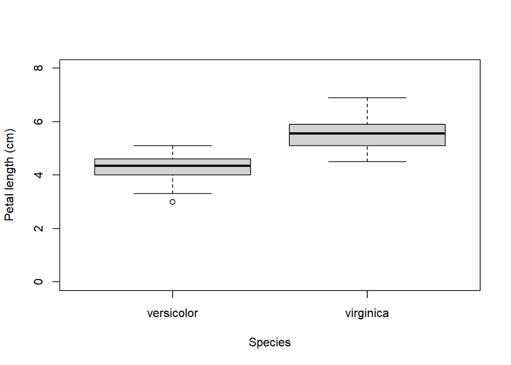

Figure 1: Boxplot showing that petal length is greater in *Iris virginica* than in *Iris versicolor*.

```r
boxplot(Petal.Length~Species, data=iris.2spp,
        xlab="Species", ylab="Petal length (cm)",
        ylim=c(0, 8))
```

## 5.2 Comparing 3 or more groups: ANOVA

### 5.2.1 One-way ANOVA

When there are 3 or more groups, we do not use a *t*-test and instead use **analysis of variance**, or **ANOVA**.

When there is only 1 explanatory **factor** (grouping variable), regardless of how many **levels** (groups) it has, the test is called a **one-way ANOVA**.

```r
mod1 <- aov(Petal.Length~Species, data=iris)
summary(mod1)
```

```
             Df Sum Sq Mean Sq F value Pr(>F)
Species       2  437.1  218.55    1180 <2e-16 ***
Residuals   147   27.2    0.19
---
Signif. codes:  0 '***' 0.001 '**' 0.01 '*' 0.05 '.' 0.1 ' ' 1
```

The `summary()` command produces the **ANOVA table**, which summarizes how the variance is partitioned between different sources. In this case, the total sum of squared deviations of all observations is $437.1 + 27.2=464.3$. ANOVA partitions that into variation due to species (437.1) and residual or “left over” variation (27.2). We sometimes think of the 437.1 as “between group” variation, and the 27.2 as “within group” variation. If there is a significant effect of species, then roughly speaking there should be more between group variation than within group variation. Really it is the variation per degree of freedom (`Df`) that defines that ratio, or $F$ statistic. Because of the way the table rounds values, it obscures the fact that $F=MS_{between}/MS_{residuals}$, or the ratio of the mean between group sums of squares and the mean within group sums of squares. The values shown, 218.55 and 0.19, are rounded so much that their quotient doesn’t equal the printed $F$ value.

**Tip**

**Rounding errors**

R is somewhat idiosyncratic in choosing how many digits it prints, and this can lead to confusion if values are rounded to too few decimal places. In the ANOVA example above, the MSE for the two sources of variation should divide to the F statistic. However, $218.55/0.19\neq1180$. If you look at the raw output of `mod1`, however, you that the sums of squares for Species and Residuals are 437.1028 and 27.2226, respectively. With more decimal places, you can then recalculate $\left(437.1028/2\right)/\left(27.2226/147\right)=1180.161$, the correct $F$ ratio.

The **omnibus test** above shows that at least 1 level, or group, of `Species` differs from one of the others. To see the tests for the pairwise differences, we have to run a **post-hoc test**. One of the most common post-hoc tests for ANOVA is Tukey’s Honest Significant Difference (HSD) test:

```r
TukeyHSD(mod1)
```

```
  Tukey multiple comparisons of means
    95% family-wise confidence level

Fit: aov(formula = Petal.Length ~ Species, data = iris)

$Species
                      diff     lwr     upr p adj
versicolor-setosa    2.798 2.59422 3.00178     0
virginica-setosa     4.090 3.88622 4.29378     0
virginica-versicolor 1.292 1.08822 1.49578     0
```

The Tukey output shows us that every group differs from every other, with *p<0.001* (here *p* is rounded to 0, although it can never be 0). The differences in group means are presented with their **95% confidence intervals (CI)**. For example, the difference between the group means of versicolor and setosa is 2.798 cm, with 95% CI = [2.594, 3.002]. Notice that none of these CI include 0: this suggests that a true difference of 0 between any two groups is very unlikely. Even without examining *p*-values, CI provide a useful way to evaluate both the direction and magnitude of differences.

One of the nice things about the Tukey HSD test is that the *p*-values are automatically adjusted for **multiple comparisons**, a phenomenon where the probability of a false positive goes up as a [researcher performs more tests](https://xkcd.com/882/), using a customized version of the probability distribution for the test statistic. This controls the **family wise error rate**, or total false positive probability for this set of three related tests.

As with a *t*-test, a boxplot is usually the best way to show the results of an ANOVA.

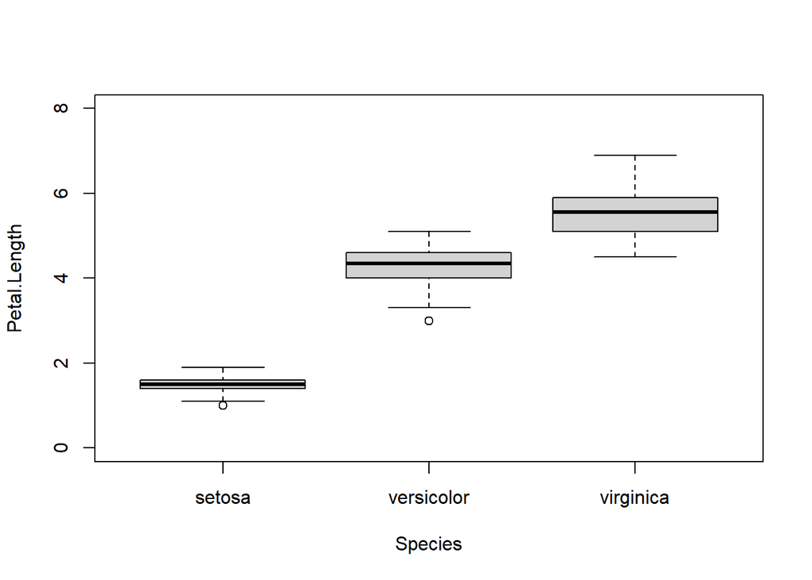

Figure 2: Boxplot showing that petal length is greater in *Iris versicolor* than in *Iris setosa*, and greater still in *Iris virginica*.

```r
boxplot(Petal.Length~Species, data=iris, ylim=c(0, 8))
```

### 5.2.2 Two-way ANOVA (and more ways)

When there are 2 or more explanatory factors, the test is called a **two-way ANOVA**, or **three-way ANOVA**, and so on. We can add additional factors to an ANOVA with the `+` sign.

```r
# make a copy of iris with an extra grouping variable
iris2 <- iris
iris2$Flower <- c("purple", "pink")

# fit the two-way ANOVA without interaction
mod2 <- aov(Petal.Length~Species+Flower, data=iris2)
summary(mod2)
```

```
             Df Sum Sq Mean Sq  F value Pr(>F)
Species       2  437.1  218.55 1174.229 <2e-16 ***
Flower        1    0.0    0.05    0.261   0.61
Residuals   146   27.2    0.19
---
Signif. codes:  0 '***' 0.001 '**' 0.01 '*' 0.05 '.' 0.1 ' ' 1
```

Adding the colors that way just repeated them until the column was full: purple, pink, purple, pink, and so on until the new vector had length 150 (the number of rows in `iris`). This essentially distributes the colors randomly with respect to the species and thus the petal lengths, so it should be no surprise that flower color had no effect on petal length ($p=0.61$). A Tukey test confirms the effects of species, and the non-effect of `Flower`. Technically, you don’t need to do or report a Tukey test if the main effect is nonsignificant.

```r
TukeyHSD(mod2, which="Species")
```

```
  Tukey multiple comparisons of means
    95% family-wise confidence level

Fit: aov(formula = Petal.Length ~ Species + Flower, data = iris2)

$Species
                      diff      lwr      upr p adj
versicolor-setosa    2.798 2.593692 3.002308     0
virginica-setosa     4.090 3.885692 4.294308     0
virginica-versicolor 1.292 1.087692 1.496308     0
```

### 5.2.3 ANOVA with ordered factors

Some factors can represent group membership, but still have an inherent ordering to them. For example, soft drinks come in sizes “small”, “medium”, and “large”. These are categories, but categories in order: small < medium < large. In contrast, the three species in the `iris` dataset have no ordering.

You may have data with a factor for age, like “juvenile”, “subadult”, “adult”. These categories correspond to ages, but cannot be treated as literal numbers of years or months. It would also be a mistake to treat the comparison of “juvenile vs. subadult” the same as the comparison of “juvenile vs. adult”.

If you analyze an ordered factor, R will estimate polynomial terms of order up to $k-1$, where $k$ is the number of factor levels. Let’s create a toy dataset to illustrate working with an ordered factor.

```r
ages <- c("juvenile", "subadult", "adult")
dx <- data.frame(age=rep(ages, each=20))
# tell R that this is an ordered factor
dx$age <- factor(dx$age, levels=ages, ordered=TRUE)

# compare this to iris$Species:
dx$age
```

```
 [1] juvenile juvenile juvenile juvenile juvenile juvenile juvenile juvenile
 [9] juvenile juvenile juvenile juvenile juvenile juvenile juvenile juvenile
[17] juvenile juvenile juvenile juvenile subadult subadult subadult subadult
[25] subadult subadult subadult subadult subadult subadult subadult subadult
[33] subadult subadult subadult subadult subadult subadult subadult subadult
[41] adult    adult    adult    adult    adult    adult    adult    adult
[49] adult    adult    adult    adult    adult    adult    adult    adult
[57] adult    adult    adult    adult
Levels: juvenile < subadult < adult
```

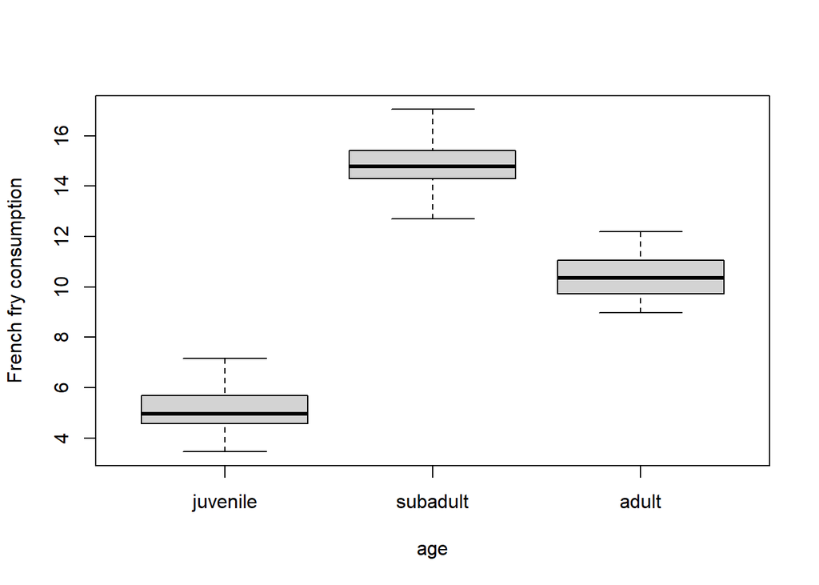

Figure 3: Boxplot showing that french fry consumption is greatest in subadults, less in adults, and lowest in juveniles.

```r
# add y values
dx$ff <- NA
dx$ff[which(dx$age=="juvenile")] <- rnorm(20, 5, 1)
dx$ff[which(dx$age=="subadult")] <- rnorm(20, 15, 1)
dx$ff[which(dx$age=="adult")] <- rnorm(20, 10, 1)

# inspect the data
boxplot(ff~age, data=dx, ylab="French fry consumption")
```

Now fit the model using the ordered factor `age`:

```r
mod11 <- aov(ff~age, data=dx)
summary(mod11)
```

```
            Df Sum Sq Mean Sq F value Pr(>F)
age          2  957.2   478.6   562.9 <2e-16 ***
Residuals   57   48.5     0.9
---
Signif. codes:  0 '***' 0.001 '**' 0.01 '*' 0.05 '.' 0.1 ' ' 1
```

The omnibus test shows us that `age` is significant. However, because we have an ordered factor, we don’t want something like a Tukey test. Instead, we want to see what patterns in `age` are significant.

```r
summary.lm(mod11)
```

```
Call:
aov(formula = ff ~ age, data = dx)

Residuals:
     Min       1Q   Median       3Q      Max
-2.18925 -0.59086 -0.08917  0.58070  2.17000

Coefficients:
            Estimate Std. Error t value Pr(>|t|)
(Intercept)  10.1206     0.1190   85.02   <2e-16 ***
age.L         3.7255     0.2062   18.07   <2e-16 ***
age.Q        -5.8292     0.2062  -28.27   <2e-16 ***
---
Signif. codes:  0 '***' 0.001 '**' 0.01 '*' 0.05 '.' 0.1 ' ' 1

Residual standard error: 0.9221 on 57 degrees of freedom
Multiple R-squared:  0.9518,    Adjusted R-squared:  0.9501
F-statistic: 562.9 on 2 and 57 DF,  p-value: < 2.2e-16
```

This analysis was simple because there were only 3 levels of `age`. When an ordered factor has many levels, you may observe “significant” polynomial trends that are biologically unimportant or difficult to interpret. It is up to you as a biologist to exercise some judgement in deciding how many terms to interpret.

## 5.3 Interactions: one variable affects another

Something we could also ask is whether there was an **interaction** between species and color: a situation where one variable changes the effect of another. Maybe purple and pink flowers really do have different petal lengths, but only in one species. Testing for an interaction would help detect that kind of pattern. To test for an interaction between two variables, use the `*` symbol instead of the `+`.

```r
# fit the two-way ANOVA WITH interaction
mod3 <- aov(Petal.Length~Species*Flower, data=iris2)
summary(mod3)
```

```
                Df Sum Sq Mean Sq  F value Pr(>F)
Species          2  437.1  218.55 1161.375 <2e-16 ***
Flower           1    0.0    0.05    0.258  0.612
Species:Flower   2    0.1    0.04    0.201  0.818
Residuals      144   27.1    0.19
---
Signif. codes:  0 '***' 0.001 '**' 0.01 '*' 0.05 '.' 0.1 ' ' 1
```

The interaction is nonsignificant, so we should instead report the main effects in the model without the interaction (`mod2`). If there is an interaction present, then it becomes impossible to discuss the effects of one variable without discussing the effects of the other. We will explore interactions more in the section on ANCOVA below.

# 6 Correlation

**Correlation** is a statistical relationship where changes in one variable are reliably associated with changes in another variable. This relationship need not be causal, hence the famous mantra, “correlation does not equal causation”. As such, correlation is usually a **descriptive technique**, which lets researchers characterize patterns, rather than an **inferential technique**, which lets researchers make estimates about unknown parameters (i.e., infer unobserved quantities).

Correlations are typically expressed as a **correlation coefficient**, a value that indicates the strength of the correlation by its magnitude and the direction of the correlation by its sign.

- **Positive correlation:** as one variable gets larger, the other variable does too. Correlation coefficient approaches $+1$.
- **Negative correlation:** as one variable gets larger, the other variable gets smaller. Correlation coefficient approaches $-1$.

When a correlation coefficient is near 0, this indicates no correlation.

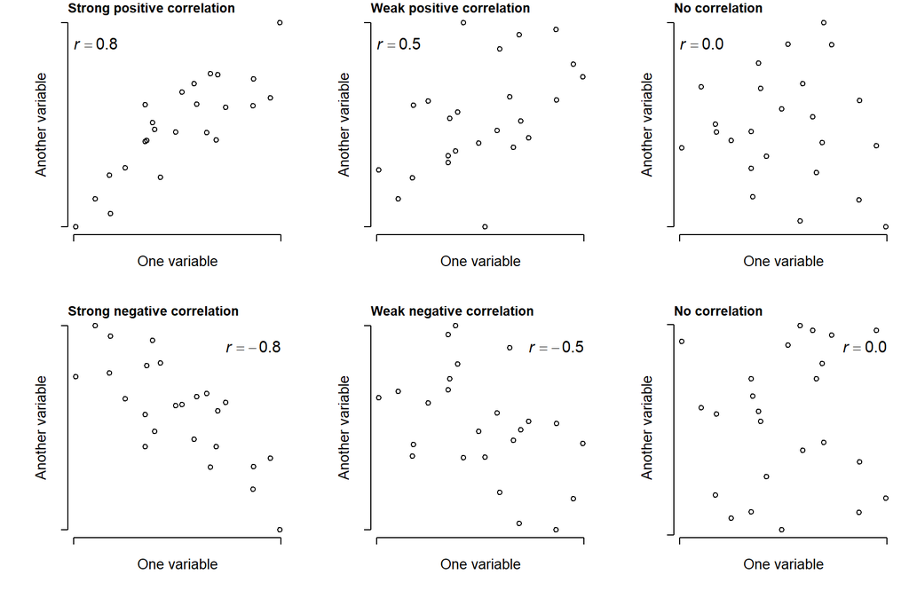

Figure 4: Illustration of possible positive and negative relationships between pairs of variables, with different levels of consistency (*r*).